# **Project #2: Polio in Modern Times**

# **Question 8, How has the vaccine affected the number of polio cases?**

Now I will utilize my second data set. This contains a combination of the percentage of the population who received a variety of different vaccines from 1962-2009. I accessed this dataset from the CDC at the following link: https://www.cdc.gov/vaccines/pubs/pinkbook/downloads/appendices/g/coverage.pdf.

I will upload the dataset using the pandas pd.read_csv() function to upload the csv as a data frame.

```python
vac = pd.read_csv("/content/cdcvaxdata.csv")
vac
```

|  | Year | DTP 3+ | DTP4+ | Polio 3+ | MMR* | Hib3+ | Var PCV3+ | HepB3+ | Combined 4-3-1 | Combined 4-3-1-3 | Unnamed: 10 |
| --- | --- | --- | --- | --- | --- | --- | --- | --- | --- | --- | --- |
| 0 | 1962 | 67.3 | NaN | NaN | NaN | NaN | NaN | NaN | NaN | NaN | NaN |
| 1 | 1963 | 71.4 | NaN | NaN | NaN | NaN | NaN | NaN | NaN | NaN | NaN |
| 2 | 1964 | 74.6 | NaN | NaN | NaN | NaN | NaN | NaN | NaN | NaN | NaN |
| 3 | 1965 | 72.7 | NaN | NaN | NaN | NaN | NaN | NaN | NaN | NaN | NaN |
| 4 | 1966 | 74.0 | NaN | NaN | NaN | NaN | NaN | NaN | NaN | NaN | NaN |
| 5 | 1967 | 77.9 | NaN | NaN | 60.0 | NaN | NaN | NaN | NaN | NaN | NaN |
| 6 | 1968 | 76.8 | NaN | NaN | 61.5 | NaN | NaN | NaN | NaN | NaN | NaN |
| 7 | 1969 | 77.4 | NaN | NaN | 61.4 | NaN | NaN | NaN | NaN | NaN | NaN |
| 8 | 1970 | 76.4 | NaN | NaN | 58.4 | NaN | NaN | NaN | NaN | NaN | NaN |
| 9 | 1971 | 77.8 | NaN | NaN | 62.2 | NaN | NaN | NaN | NaN | NaN | NaN |
| 10 | 1972 | 74.1 | NaN | NaN | 62.8 | NaN | NaN | NaN | NaN | NaN | NaN |
| 11 | 1973 | 71.7 | NaN | 59.5 | 61.0 | NaN | NaN | NaN | NaN | NaN | NaN |
| 12 | 1974 | 72.4 | NaN | 60.0 | 63.4 | NaN | NaN | NaN | NaN | NaN | NaN |
| 13 | 1975 | 73.2 | NaN | 63.6 | 65.5 | NaN | NaN | NaN | NaN | NaN | NaN |
| 14 | 1976 | 72.7 | NaN | 61.3 | 66.3 | NaN | NaN | NaN | NaN | NaN | NaN |
| 15 | 1977 | 69.6 | NaN | 62.6 | 65.0 | NaN | NaN | NaN | NaN | NaN | NaN |
| 16 | 1978 | 66.6 | NaN | 59.5 | 63.6 | NaN | NaN | NaN | NaN | NaN | NaN |
| 17 | 1979 | 64.4 | NaN | 59.7 | 66.5 | NaN | NaN | NaN | NaN | NaN | NaN |
| 18 | 1980 | 66.0 | NaN | 58.9 | 66.6 | NaN | NaN | NaN | NaN | NaN | NaN |
| 19 | 1981 | 68.1 | NaN | 59.2 | 66.8 | NaN | NaN | NaN | NaN | NaN | NaN |
| 20 | 1982 | 67.1 | NaN | 57.0 | 67.6 | NaN | NaN | NaN | NaN | NaN | NaN |
| 21 | 1983 | 65.4 | NaN | 56.9 | 66.3 | NaN | NaN | NaN | NaN | NaN | NaN |
| 22 | 1984 | 65.0 | NaN | 53.2 | 65.8 | NaN | NaN | NaN | NaN | NaN | NaN |
| 23 | 1985 | 63.6 | NaN | 53.6 | 61.2 | NaN | NaN | NaN | NaN | NaN | NaN |
| 24 | 1986 | NaN | NaN | NaN | NaN | NaN | NaN | NaN | NaN | NaN | NaN |
| 25 | 1987 | NaN | NaN | NaN | NaN | NaN | NaN | NaN | NaN | NaN | NaN |
| 26 | 1988 | NaN | NaN | NaN | NaN | NaN | NaN | NaN | NaN | NaN | NaN |
| 27 | 1989 | NaN | NaN | NaN | NaN | NaN | NaN | NaN | NaN | NaN | NaN |
| 28 | 1990 | NaN | NaN | NaN | NaN | NaN | NaN | NaN | NaN | NaN | NaN |
| 29 | 1991 | 68.8 | NaN | 53.2 | 82.0 | NaN | NaN | NaN | NaN | NaN | NaN |
| 30 | 1992 | 83.0 | 59.0 | 72.4 | 82.5 | 28.2 | NaN | NaN | 8.0 | 68.7 | 55.3 |
| 31 | 1993 | 88.2 | 72.1 | 78.9 | 84.1 | 55.0 | NaN | NaN | 16.3 | 67.1 | NaN |
| 32 | 1994 | 93.0 | 77.7 | 83.0 | 89.0 | 86.0 | NaN | NaN | 37.0 | 75.0 | NaN |
| 33 | 1995 | 94.7 | 78.5 | 87.9 | 87.6 | 91.7 | NaN | NaN | 68.0 | 76.2 | 74.2 |
| 34 | 1996 | 95.0 | 81.1 | 91.1 | 90.7 | 91.7 | 16.0 | NaN | 81.8 | 78.4 | 76.5 |
| 35 | 1997 | 95.5 | 81.5 | 90.8 | 90.5 | 92.7 | 25.9 | NaN | 83.7 | 77.9 | 76.2 |
| 36 | 1998 | 95.6 | 83.9 | 90.8 | 92.0 | 93.4 | 43.2 | NaN | 87.0 | 80.6 | 79.2 |
| 37 | 1999 | 95.9 | 83.3 | 89.6 | 91.5 | 93.5 | 57.5 | NaN | 88.1 | 79.9 | 78.4 |
| 38 | 2000 | 94.1 | 81.7 | 89.5 | 90.5 | 93.4 | 67.8 | NaN | 90.3 | 77.6 | 76.2 |
| 39 | 2001 | 94.3 | 82.1 | 89.4 | 91.4 | 93.0 | 76.3 | NaN | 88.9 | 78.6 | 77.2 |
| 40 | 2002 | 94.9 | 81.6 | 90.2 | 91.6 | 93.1 | 80.6 | 40.8 | 88.9 | 78.5 | 77.5 |
| 41 | 2003 | 96.0 | 84.8 | 91.6 | 93.0 | 93.9 | 84.8 | 68.1 | 92.4 | 82.2 | 81.3 |
| 42 | 2004 | 95.9 | 85.5 | 91.6 | 93.0 | 93.5 | 87.5 | 73.2 | 92.4 | 83.5 | 82.5 |
| 43 | 2005 | 96.1 | 85.7 | 91.7 | 91.5 | 93.9 | 87.9 | 82.8 | 92.9 | 83.1 | 82.4 |
| 44 | 2006 | 95.8 | 85.2 | 92.9 | 92.4 | 93.4 | 89.3 | 87.0 | 93.4 | 83.2 | 82.3 |
| 45 | 2007 | 95.5 | 84.5 | 92.6 | 92.3 | 92.6 | 90.0 | 90.0 | 92.7 | 82.8 | 81.1 |
| 46 | 2008 | NaN | 84.6 | 93.6 | 92.1 | 90.9 | 90.7 | 80.1 | 93.5 | NaN | NaN |
| 47 | 2009 | 94.0 | 83.9 | 92.8 | 90.0 | 92.1 | 89.6 | 92.6 | 92.4 | 81.5 | NaN |

For the purposes of this analysis, we will be looking at the Polio 3+ column, showing the rates at which the population has received the three-dose live vaccine against Polio. I will do this by specifically selecting the Year and Polio 3+ column, which refers to the year in question and the percentage of the U.S. population who received the 3-shot polio vaccine.

```python
vac[['Year','Polio 3+']]
```

|  | Year | Polio 3+ |
| --- | --- | --- |
| 0 | 1962 | NaN |
| 1 | 1963 | NaN |
| 2 | 1964 | NaN |
| 3 | 1965 | NaN |
| 4 | 1966 | NaN |
| 5 | 1967 | NaN |
| 6 | 1968 | NaN |
| 7 | 1969 | NaN |
| 8 | 1970 | NaN |
| 9 | 1971 | NaN |
| 10 | 1972 | NaN |
| 11 | 1973 | 59.5 |
| 12 | 1974 | 60.0 |
| 13 | 1975 | 63.6 |
| 14 | 1976 | 61.3 |
| 15 | 1977 | 62.6 |
| 16 | 1978 | 59.5 |
| 17 | 1979 | 59.7 |
| 18 | 1980 | 58.9 |
| 19 | 1981 | 59.2 |
| 20 | 1982 | 57.0 |
| 21 | 1983 | 56.9 |
| 22 | 1984 | 53.2 |
| 23 | 1985 | 53.6 |
| 24 | 1986 | NaN |
| 25 | 1987 | NaN |
| 26 | 1988 | NaN |
| 27 | 1989 | NaN |
| 28 | 1990 | NaN |
| 29 | 1991 | 53.2 |
| 30 | 1992 | 72.4 |
| 31 | 1993 | 78.9 |
| 32 | 1994 | 83.0 |
| 33 | 1995 | 87.9 |
| 34 | 1996 | 91.1 |
| 35 | 1997 | 90.8 |
| 36 | 1998 | 90.8 |
| 37 | 1999 | 89.6 |
| 38 | 2000 | 89.5 |
| 39 | 2001 | 89.4 |
| 40 | 2002 | 90.2 |
| 41 | 2003 | 91.6 |
| 42 | 2004 | 91.6 |
| 43 | 2005 | 91.7 |
| 44 | 2006 | 92.9 |
| 45 | 2007 | 92.6 |
| 46 | 2008 | 93.6 |
| 47 | 2009 | 92.8 |

Next, for some basic information I will calculate the mean, average, standard deviation, minimum and maximum of polio 3+ column. However, some of these are completely irrelevant, given the format of the data frame.

```python
vac.mean()
```

```
Year                1985.500000
DTP 3+                80.297619
DTP4+                 80.927778
Polio 3+              75.581250
MMR*                  76.831579
Hib3+                 86.777778
Var PCV3+             70.507143
HepB3+                76.825000
Combined 4-3-1        77.094444
Combined 4-3-1-3      78.517647
Unnamed: 10           77.164286
dtype: float64
```

```python
vac.std()
```

```
Year                14.000000
DTP 3+              12.117121
DTP4+                6.436642
Polio 3+            16.028954
MMR*                13.566953
Hib3+               17.161193
Var PCV3+           25.297354
HepB3+              16.730874
Combined 4-3-1      27.256483
Combined 4-3-1-3     4.746872
Unnamed: 10          6.848763
dtype: float64
```

```python
vac.min()
```

```
Year                1962.0
DTP 3+                63.6
DTP4+                 59.0
Polio 3+              53.2
MMR*                  58.4
Hib3+                 28.2
Var PCV3+             16.0
HepB3+                40.8
Combined 4-3-1         8.0
Combined 4-3-1-3      67.1
Unnamed: 10           55.3
dtype: float64
```

```python
vac.max()
```

```
Year                2009.0
DTP 3+                96.1
DTP4+                 85.7
Polio 3+              93.6
MMR*                  93.0
Hib3+                 93.9
Var PCV3+             90.7
HepB3+                92.6
Combined 4-3-1        93.5
Combined 4-3-1-3      83.5
Unnamed: 10           82.5
dtype: float64
```

Next, I will plot the data to compare the percentage of the population versus the year using the Pandas df.plot() function.

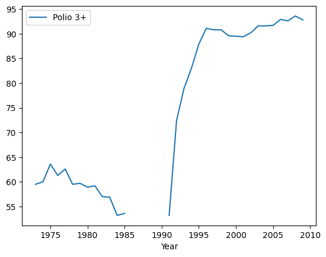

```python
vac.plot(x='Year', y='Polio 3+')
```

Viewing the years is quite strange, so I will graph it as a df.plot.bar() for a bar graph visual of each individual year.

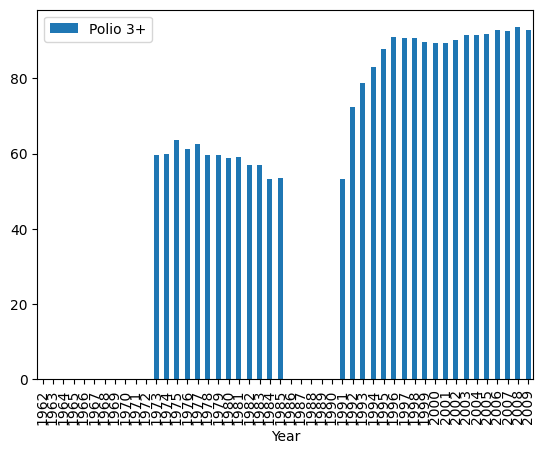

```python
vac.plot.bar(x='Year', y='Polio 3+')
```

Now we will look at the years in which the highest case counts were reported on the initial dataset.

```python
sum
```

```
1980             371098.0
1981             462511.0
1982             363720.0
1983             281568.0
1984             246512.0
1985             270095.0
1986             230195.0
1987             277935.0
1988             241911.0
1989             155695.0
1990             131769.0
1991              83709.0
1992             101345.0
1993              74991.0
1994              62335.0
```

[output cut: 29 more lines]

# **Answer to Question 8:**

# **Question 9, How did the introduction of the vaccine impact the number of cases in the U.S.**

I am going to compare the number of polio cases in the U.S. against the percentage of the population vaccinated and see if there is a correlation between the two.

I will use df.loc to locate the row where the U.S. cases are, using the == operator to return the row where the country name is the United States.

```python
US = df.loc[(df['Country'] == 'United States')]
US
```

|  | Country | 1980 | 1981 | 1982 | 1983 | 1984 | 1985 | 1986 | 1987 | 1988 | ... | 2015 | 2016 | 2017 | 2018 | 2019 | 2020 | Total Result | 1980-1984 | 2016-2020 | difference_firstlast5 |
| --- | --- | --- | --- | --- | --- | --- | --- | --- | --- | --- | --- | --- | --- | --- | --- | --- | --- | --- | --- | --- | --- |
| 142 | United States | 56.0 | 42.0 | 56.0 | 105.0 | 56.0 | 49.0 | 63.0 | 0.0 | 0.0 | ... | 0.0 | 0.0 | 0.0 | 0.0 | 0.0 | 0.0 | 427 | 315.0 | 0.0 | -315.0 |

1 rows × 46 columns

Now we will use the .loc[] function to select only the years between 1980 and 2000.

```python
vac.loc[(vac['Year'] > 1979) & (vac['Year'] < 2001)][['Year','Polio 3+']]
```

|  | Year | Polio 3+ |
| --- | --- | --- |
| 18 | 1980 | 58.9 |
| 19 | 1981 | 59.2 |
| 20 | 1982 | 57.0 |
| 21 | 1983 | 56.9 |
| 22 | 1984 | 53.2 |
| 23 | 1985 | 53.6 |
| 24 | 1986 | NaN |
| 25 | 1987 | NaN |
| 26 | 1988 | NaN |
| 27 | 1989 | NaN |
| 28 | 1990 | NaN |
| 29 | 1991 | 53.2 |
| 30 | 1992 | 72.4 |
| 31 | 1993 | 78.9 |
| 32 | 1994 | 83.0 |
| 33 | 1995 | 87.9 |
| 34 | 1996 | 91.1 |
| 35 | 1997 | 90.8 |
| 36 | 1998 | 90.8 |
| 37 | 1999 | 89.6 |
| 38 | 2000 | 89.5 |

Notice the abrupt increase in the vaccinated percentage from 1991-1992, as it climbed after a relatively stable percentage from 1980-1990. However, did the increase in vaccine distribution result in a lower number of cases?

```python
US[['Country','1980','1981','1982','1983','1984','1985','1991','1992','1993','1994','Total Result']]
```

|  | Country | 1980 | 1981 | 1982 | 1983 | 1984 | 1985 | 1991 | 1992 | 1993 | 1994 | Total Result |
| --- | --- | --- | --- | --- | --- | --- | --- | --- | --- | --- | --- | --- |
| 142 | United States | 56.0 | 42.0 | 56.0 | 105.0 | 56.0 | 49.0 | 0.0 | 0.0 | 0.0 | 0.0 | 427 |

Now we will look at the cases of polio during the years where the U.S. did not report any Polio 3+ vaccine data.

```python
US[['Country','1987','1988','1989','1990','Total Result']]
```

|  | Country | 1987 | 1988 | 1989 | 1990 | Total Result |
| --- | --- | --- | --- | --- | --- | --- |
| 142 | United States | 0.0 | 0.0 | 0.0 | 0.0 | 427 |

What is interesting to note is that the United States had not reported any cases around the time of the large rise in childhood vaccination. Perhaps to spark the initiative, the CDC did not report the number of cases to validate the efficacy of the vaccine.

# **Answer to Question 9:**

I have reason to believe that the number of cases reported before the rapid increase in vaccinated population from mandates is misreported, as there was a sudden dropoff of roughly 50 cases per year down to 0, and there is no obvious reason for this shift. Although the vaccine was released to the public during the 1960's, only about half received it, making the sudden drop in cases highly unlikely. As the CDC did not track the progress of the vaccine to the public during the years of 1986-1990, it is likely that they also neglected to count the number of cases for budgeting reasons. However, it is also possible that it was misreported to aid the marketing of the vaccine, although this is simply speculation.

# **Question 10, Why did the tracking of vaccine distribution in the U.S. took a sudden halt in the late 1980's?**

The gaps in the data graph are intriguing, so I think it would be interesting to locate the reason why no data was reported during this 5-year gap in the late 1980s.

To begin this analysis, I think it is necessary to first look at the distribution of the other vaccines in the dataset to see if it was the same across the market as an outside issue.

```python
vac.columns
```

```
Index(['Year', 'DTP 3+', 'DTP4+', 'Polio 3+', 'MMR*', 'Hib3+', 'Var PCV3+',
       'HepB3+', 'Combined 4-3-1', 'Combined 4-3-1-3', 'Unnamed: 10'],
      dtype='object')
```

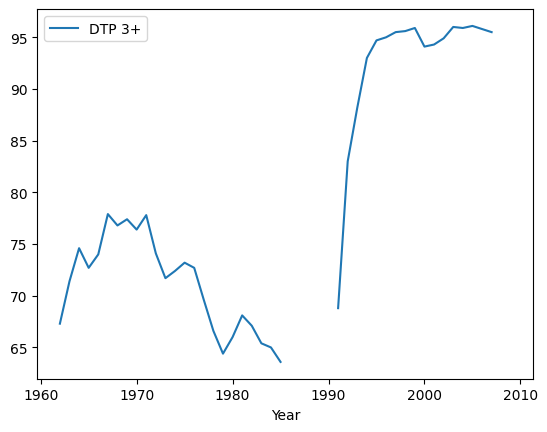

```python
vac.plot(x='Year', y='DTP 3+')
```

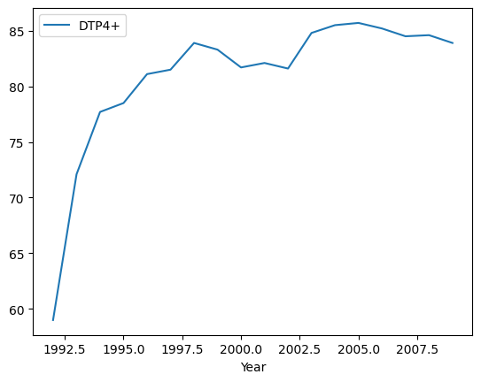

```python
vac.plot(x='Year', y='DTP4+')
```

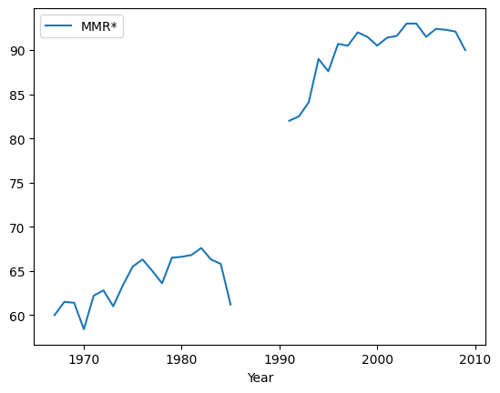

```python
vac.plot(x='Year', y='MMR*')
```

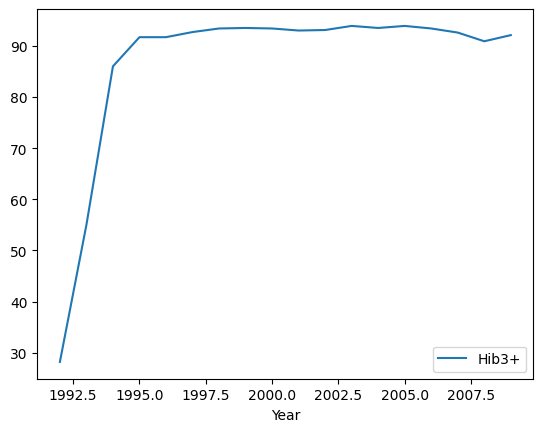

```python
vac.plot(x='Year', y='Hib3+')
```

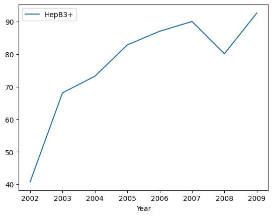

```python
vac.plot(x='Year', y='HepB3+')
```

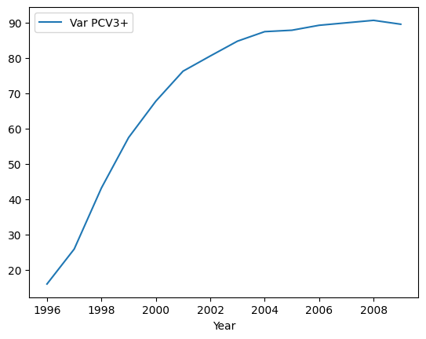

```python
vac.plot(x='Year', y='Var PCV3+')
```

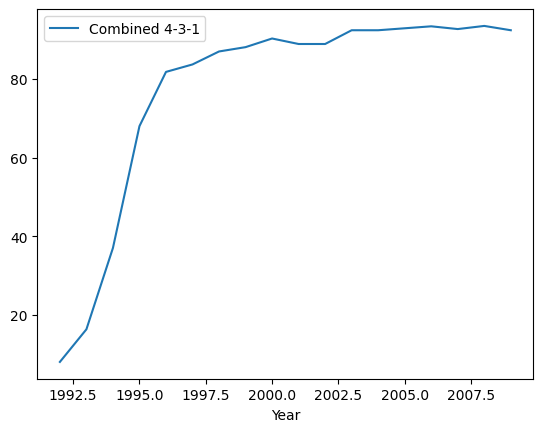

```python
vac.plot(x='Year', y='Combined 4-3-1')
```

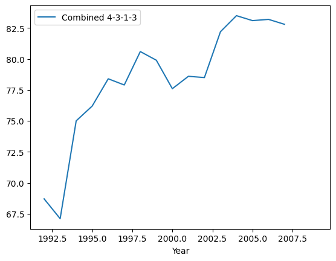

```python
vac.plot(x='Year', y='Combined 4-3-1-3')
```

The columns 4-3-1 and 4-3-1-3 are simply the percentage of the population that received a combination of the other vaccines, and they are irrelevant to the sudden dip in distribution among the general public in the 1980's.

# **Answer to Question 10:**

All of the vaccines that were tracked back in the 1980s did not report the data for the years 1986–1990. Doing some outside research, those were years of economic turmoil for the U.S., as funding for the CDC was likely removed or deemed unnecessary. Furthermore, in the early 1990s, initiatives were made to mandate specific vaccines for children, and the polio 3+ vaccine was among those mandated. This can be seen in the CDC article at the link: https://www.cdc.gov/mmwr/preview/mmwrhtml/00039897.htm. However, the campaigning for children to receive vaccines was already in progress prior to the official mandate. Therefore, I would conclude that the lack of tracking the population who received the vaccine was not individual to the polio 3+ vaccine.

# **Summary**